# alien_native_competition

Zhijie Zhang

March 15, 2019

Zhijie Zhang and Mark van Kleunen, Common alien plants are more competitive than rare natives but not than common natives, Ecology Letters - ELE-00305-2019.R1.

**Experimental design**: We let 48 pairs of alien and native species to compete with a response surface design (varying total density and frequency). The species are either common or rare in Germany.

**Main results**:

1. Competitive outcomes (pot level), When growing together, common aliens had higher biomass (i.e. were more competitive) than rare natives
2. three determinants of competitive outcomes (individual levels)
   - Intrinsic growth rates: aliens had higher biomass than natives, and commons had higher biomass than rares.
   - intraspecific competition: aliens experienced higher intraspecific competition than natives. This is mainly driven by the strong intraspecific compeition of common aliens.
   - interspecific competition: there is a weak trend that aliens experienced weaker interspecific competition than natives.

**Methods**:

1. Competitive outcomes. First summarize the difference in total biomass between alien and native species in bi-culture for each combination (pair). Then analyze the associations between competitive outcome and status & commonness.
2. Three determinants. First parameterize the competitive coefficients (lambda & alpha) for each species per combination, and then analyze the associations between parameters and status & commonness.

data preparation

```r
knitr::opts_chunk$set(warning = FALSE,message = FALSE)
library(xlsx)
library(lme4)
library(dplyr)
library(r2glmm)
library(knitr)
setwd("D:/0_phd/experiment/01response_surface/final_exp/data")
# metadata
# spp_target: species of target species; spp_comp: species of competitor species;
# biomass: aboveground biomass of target species, mg as the unit;
# comb: combinition (species pair) ID;
# status: status of target species, alien or native;
# common: commonness of target species, common or rare; common_comp: commonness of competitor species;
# family: family of target species; family_comp: family of competitor species;
# density: total density at the end of growing season; freq: frequence of target species at the end of growing season;
# density_in: total density at the beginning of experiment; freq_in: frequence of target species at the beginning of experiment;
# no_target: number of conspecific competitors (e.g. if there are n individuals of target species, no_target = n-1) in the pot at he end of growing season; no_comp: number of heterospecific competitors at the end of growing season;
# no_target_in: number of conspecific competitors at the beginning of experiment; no_comp: number of heterospecific competitors at the beginning of experiment;
# pot: pot ID
# record: year of 1st record
dat0<-read.csv("biomass.csv")#biomass data
dat_rec<-read.csv("recruit.csv")#recruit data
resid_time<-read.csv("resid_time.csv")# residence time
```

# 1 competitive outcome

compare the biomass of alien and native in bi-culture  
Note that, after tranforming the data, “target species” is always the alien, and “competitor species” is always the native

```r
#calculate total biomass per pot per species
dat0<-dat0[!is.na(dat0$biomass),]
dat_mean<-dat0 %>%
  group_by(pot,spp_target,common,common_comp,status,spp_comp,family,family_comp,comb,freq_in,density_in,freq,density) %>%
  summarise(tb = sum(biomass))
# exclude mono, calculate log alien/native
alien_mean<-dat_mean%>%
  filter(status=="alien",freq_in!=1)
native_mean<-dat_mean%>%
  filter(status=="native",freq_in!=1)%>%
  ungroup()%>%
  dplyr::select(pot,tb)
# combine native and alien total biomass by pot,
# note that "target species" is always the alien, and "competitor species" is always the native
dat_diff<-inner_join(alien_mean,native_mean,by=c("pot"))


dat_diff<-dat_diff%>%
  mutate(tb_diff=log(tb.x/tb.y))
```

## 1.1 table

```r
# informations
table.diff<-distinct(dat_diff[,2:9])
# data to calculate
table.diff$value<-0
table.diff$se<-0
table.diff$df<-0
for (i in 1:length(table.diff$comb)){
  dat.i<-filter(dat_diff,comb==table.diff$comb[i])
  m.i<-lm(tb_diff~1,data=dat.i)
  r.i<-summary(m.i)
  table.diff$value[i]<-r.i$coefficients[1]
  table.diff$se[i]<-r.i$coefficients[2]
  table.diff$df[i]<-nrow(dat.i)-1
}


#models
#full model
m.diff_r1<-lmer(value~common*common_comp+(1|family/spp_target)+(1|family_comp/spp_comp),
                      weights = 1/(se^2*df),#variance
                      data=table.diff)


# without 2ways
m.diff_r2<-update(m.diff_r1,.~.-common:common_comp)

m.diff_r3<-lmer(value~-1+(1|family/spp_target)+(1|family_comp/spp_comp),
                      weights = 1/(se^2*df),
                      data=table.diff)

#2-way
res.diff_r1<-drop1(m.diff_r1,test="Chisq")[-1,]
#main
res.diff_r2<-drop1(m.diff_r2,test="Chisq")
#intercept, i.e. global differences between alien and natives
res.diff_r3<-anova(m.diff_r3,update(m.diff_r2,.~.-common-common_comp))[-1,]

rownames(res.diff_r2)[1]<-"intercept"
res.diff_r2$Df[1]<-1
res.diff_r2$AIC[1]<-NA
res.diff_r2$LRT[1]<-res.diff_r3$Chisq
res.diff_r2$`Pr(Chi)`[1]<-res.diff_r3$`Pr(>Chisq)`

#table
rbind(res.diff_r2,res.diff_r1)%>%
  kable(caption="effect size ~ commonness of alien* commonness of native",digits=3)
```

effect size ~ commonness of alien* commonness of native

|  | Df | AIC | LRT | Pr(Chi) |
| --- | --- | --- | --- | --- |
| intercept | 1 | NA | 2.085 | 0.149 |
| common | 1 | 100.473 | 3.608 | 0.058 |
| common_comp | 1 | 100.314 | 3.450 | 0.063 |
| common:common_comp | 1 | 98.864 | 0.043 | 0.835 |

```r
cat("variation explained by fixed effects")
```

```
## variation explained by fixed effects
```

```r
r2beta(m.diff_r1)
```

```
##                       Effect   Rsq upper.CL lower.CL
## 1                      Model 0.364    0.571    0.194
## 3            common_comprare 0.198    0.408    0.042
## 2                 commonrare 0.038    0.203    0.000
## 4 commonrare:common_comprare 0.000    0.103    0.000
```

## 1.2 add residence time

```r
table.diff.resid<-table.diff%>%
  left_join(resid_time,by=c("spp_target"="Species"))
m.diff_r1<-lmer(value~record+common*common_comp+(1|family/spp_target)+(1|family_comp/spp_comp),
                      weights = 1/(se^2*df),
                      data=table.diff.resid)

m.diff_r2<-update(m.diff_r1,.~.-common_comp:common)
m.diff_r3<-update(m.diff_r2,.~.-common_comp-common)

#2-way
res.diff_r1<-drop1(m.diff_r1,test="Chisq")[-c(1:2),]
#main
res.diff_r2<-drop1(m.diff_r2,test="Chisq")[-c(1:2),]
#covariate
res.diff_r3<-drop1(m.diff_r3,test="Chisq")[-1,]

cat("difference in residence time between common and rare aliens")
```

```
## difference in residence time between common and rare aliens
```

```r
kruskal.test(resid_time$record,resid_time$Commonness)
```

```
##
##  Kruskal-Wallis rank sum test
##
## data:  resid_time$record and resid_time$Commonness
## Kruskal-Wallis chi-squared = 0.06, df = 1, p-value = 0.8065
```

```r
rbind(res.diff_r3,res.diff_r2,res.diff_r1)%>%
  kable(caption="effect size ~ commonness of alien* commonness of native",digits=3)
```

effect size ~ commonness of alien* commonness of native

|  | Df | AIC | LRT | Pr(Chi) |
| --- | --- | --- | --- | --- |
| record | 1 | 101.992 | 1.967 | 0.161 |
| common | 1 | 100.362 | 2.717 | 0.099 |
| common_comp | 1 | 101.235 | 3.590 | 0.058 |
| common:common_comp | 1 | 99.645 | 0.041 | 0.840 |

```r
cat("variation explained by fixed effects")
```

```
## variation explained by fixed effects
```

```r
r2beta(m.diff_r1)
```

```
##                       Effect   Rsq upper.CL lower.CL
## 1                      Model 0.374    0.584    0.213
## 4            common_comprare 0.200    0.410    0.043
## 3                 commonrare 0.023    0.172    0.000
## 2                     record 0.021    0.168    0.000
## 5 commonrare:common_comprare 0.000    0.103    0.000
```

## 1.3 figure 4

positive y means alien had higher biomass in competition

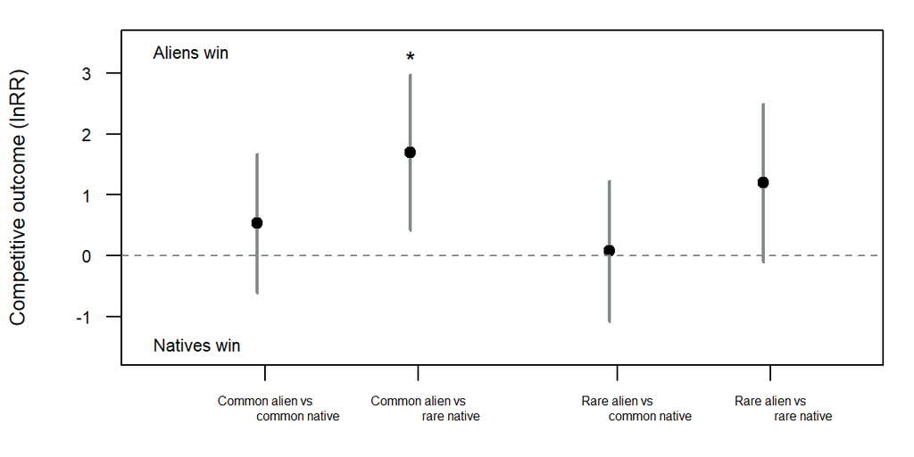

```r
#prepare
t.diff<-as.data.frame(coef(summary(lmer(value~common_comp:common-1+(1|family/spp_target)+(1|family_comp/spp_comp),weights = 1/(se^2*df),data=table.diff))))
colnames(t.diff)[1:2]<-c("mean","se")
#for bar
x<-c(0.5,1.5,2.8,3.8)

# plot


par(mar=c(3,4,1,1))
plot(x+0.2,t.diff$mean,ylim=c(-1.6,3.5),xlim=c(0,4.6),pch=19,xaxt="n",yaxt="n",
     ylab="Competitive outcome (lnRR)",xlab="",cex.lab=0.8)

arrows(x+0.2,t.diff$mean+1.96*t.diff$se,x+0.2,t.diff$mean-1.96*t.diff$se,angle=90,code=3,length=0,lwd=2,col="azure4")
points(x+0.2,t.diff$mean,ylim=c(-1.6,3.5),xlim=c(0,4),pch=19,cex=1)
axis(1,at=x+0.25,labels=c("Common alien vs
                     common native","Common alien vs
                     rare native","Rare alien vs
                     common native","Rare alien vs
                     rare native"
),cex.axis=0.5)
axis(2,at=c(-1,0,1,2,3),labels = c(-1,0,1,2,3),las=2,cex.axis=0.7)
abline(h=0,lty=2, col="azure4",cex=1.5)#y=0
legend("topleft","Aliens win",bty="n",cex=0.7)
legend("bottomleft","Natives win",bty="n",cex=0.7)
text(1.7,3.3,"*")
```

# 2 three determinants

first get parameters for each combination with Ricker model, then analyze the parameters

## 2.1 fit lambda and alpha for species per combination

```r
table.alien<-as.data.frame(matrix(,0,6))
table.native<-as.data.frame(matrix(,0,6))

for (i in 1:48){
  # data of pair i
  dat.i<-subset(dat0,comb==i)
  # data of all native/alien individuals in pair i
  native.i<-subset(dat.i,status=="native")
  alien.i<-subset(dat.i,status=="alien")
  # fit the ricker model
  m.native.i<-lmer(log(biomass)~no_target+no_comp+(1|pot),data=native.i)
  m.alien.i<-lmer(log(biomass)~no_target+no_comp+(1|pot),data=alien.i)
  s.native.i<-summary(m.native.i)
  s.alien.i<-summary(m.alien.i)
  # extract the data
  table.alien<-rbind(table.alien,cbind(s.alien.i$coefficient,i))
  table.native<-rbind(table.native,cbind(s.native.i$coefficient,i))
}

t.par<-as.data.frame(rbind(table.alien,table.native))

t.par$status<-rep(c("alien","native"),each=nrow(t.par)/2)
t.par$par<-rep(c("intercept","alphaii","alphaij"),nrow(t.par)/3)
#get common rare species info
dat_par<-dat0%>%
  dplyr::select(status,common,common_comp,family,family_comp,spp_target,spp_comp,pot,comb)%>%
  distinct()%>%
  group_by(status,common,common_comp,family,family_comp,spp_target,spp_comp,comb)%>%
  summarise(df=n()-3)%>%# degree of freedom
  right_join(t.par,by=c("comb"="i","status"="status"))%>%
  rename("se"="Std. Error")
dat_par$comb<-factor(dat_par$comb)
dat.lambda<-subset(dat_par,par=="intercept")
dat.ii<-subset(dat_par,par=="alphaii")
dat.ij<-subset(dat_par,par=="alphaij")
```

## 2.2 lambda or alpha~ status *commonness

### 2.2.1 table

```r
# analyze
## lambda
m.lambda<-lmer(Estimate~status*common+(1|family/spp_target)+(1|comb),
               weights = 1/(se^2*df),
               data=dat.lambda)

m.lambda_r2<-update(m.lambda,.~.-status:common)
## ii
m.ii<-lmer(Estimate~status*common+(1|family/spp_target)+(1|comb),
           weights = 1/(se^2*df),
           data=dat.ii)
m.ii_r2<-update(m.ii,.~.-status:common)
## ij
m.ij<-lmer(Estimate~status*common*common_comp+(1|family/spp_target)+(1|family_comp/spp_comp)+(1|comb),
           weights = 1/(se^2*df),
           control=lmerControl(optimizer ='bobyqa', optCtrl=list(maxfun=500000)),
           data=dat.ij)
m.ij_r2<-update(m.ij,.~.-status:common:common_comp)
m.ij_r3<-lmer(Estimate~status+common+common_comp+(1|family/spp_target)+(1|family_comp/spp_comp)+(1|comb),
              weights = 1/(se^2*df),
              control=lmerControl(optimizer ='bobyqa', optCtrl=list(maxfun=500000)),
              data=dat.ij)

# drop1
# lambda
lam_r1<-drop1(m.lambda,test="Chisq")[-1,]
lam_r2<-drop1(m.lambda_r2,test="Chisq")[-1,]

#ii
ii_r1<-drop1(m.ii,test="Chisq")[-1,]
ii_r2<-drop1(m.ii_r2,test="Chisq")[-1,]

#ij
ij_r1<-drop1(m.ij,test="Chisq")[-1,]
#2way
ij_r2<-drop1(m.ij_r2,,test="Chisq")[-1,]
#main
ij_r3<-drop1(m.ij_r3,,test="Chisq")[-1,]


rbind(lam_r2,lam_r1)%>%
  kable(caption="lambda",digit=3)
```

lambda

|  | Df | AIC | LRT | Pr(Chi) |
| --- | --- | --- | --- | --- |
| status | 1 | 203.792 | 8.812 | 0.003 |
| common | 1 | 201.155 | 6.174 | 0.013 |
| status:common | 1 | 196.980 | 1.370 | 0.242 |

```r
rbind(ii_r2,ii_r1)%>%
  kable(caption="alphaii",digit=3)
```

alphaii

|  | Df | AIC | LRT | Pr(Chi) |
| --- | --- | --- | --- | --- |
| status | 1 | -301.218 | 4.943 | 0.026 |
| common | 1 | -305.756 | 0.405 | 0.525 |
| status:common | 1 | -304.161 | 4.095 | 0.043 |

```r
rbind(ij_r3,ij_r2,ij_r1)%>%
  kable(caption="alphaij",digit=3)
```

alphaij

|  | Df | AIC | LRT | Pr(Chi) |
| --- | --- | --- | --- | --- |
| status | 1 | -265.333 | 1.975 | 0.160 |
| common | 1 | -267.255 | 0.054 | 0.817 |
| common_comp | 1 | -266.599 | 0.709 | 0.400 |
| status:common | 1 | -262.047 | 0.452 | 0.502 |
| status:common_comp | 1 | -262.456 | 0.042 | 0.837 |
| common:common_comp | 1 | -261.874 | 0.625 | 0.429 |
| status:common:common_comp | 1 | -260.498 | 0.003 | 0.956 |

```r
cat("variations explained by fixed effects")
```

```
## variations explained by fixed effects
```

```r
r2beta(m.lambda,method='sgv')
```

```
##                    Effect   Rsq upper.CL lower.CL
## 1                   Model 0.439    0.573    0.314
## 2            statusnative 0.102    0.235    0.018
## 3              commonrare 0.049    0.161    0.001
## 4 statusnative:commonrare 0.044    0.154    0.001
```

```r
r2beta(m.ii,method='sgv')
```

```
##                    Effect   Rsq upper.CL lower.CL
## 1                   Model 0.067    0.208    0.016
## 2            statusnative 0.066    0.187    0.004
## 4 statusnative:commonrare 0.029    0.128    0.000
## 3              commonrare 0.021    0.111    0.000
```

```r
r2beta(m.ij,method='sgv')
```

```
##                                    Effect   Rsq upper.CL lower.CL
## 1                                   Model 0.030    0.197    0.025
## 2                            statusnative 0.008    0.082    0.000
## 7              commonrare:common_comprare 0.002    0.061    0.000
## 5                 statusnative:commonrare 0.001    0.056    0.000
## 3                              commonrare 0.000    0.054    0.000
## 4                         common_comprare 0.000    0.053    0.000
## 8 statusnative:commonrare:common_comprare 0.000    0.052    0.000
## 6            statusnative:common_comprare 0.000    0.052    0.000
```

### 2.2.2 figure 3

```r
#lambda, unit as mg
lambda<-as.data.frame(coef(summary(lmer(Estimate~common:status-1+(1|family/spp_target)+(1|comb),
               weights = 1/(se^2*df),
               data=dat.lambda))))
names(lambda)[1:2]<-c("mean","se")

#alphaii
alphaii_sp<-aggregate(-Estimate~common+status+spp_target+family,data=dat.ii,FUN=mean)
colnames(alphaii_sp)[5]<-"mean"
alphaii<-as.data.frame(coef(summary(lmer(-Estimate~common:status-1+(1|family/spp_target)+(1|comb),
               weights = 1/(se^2*df),
               data=dat.ii))))
names(alphaii)[1:2]<-c("mean","se")

# alphaij
alphaij<-as.data.frame(coef(summary(lmer(-Estimate~common:status-1+(1|family/spp_target)+(1|comb),
               weights = 1/(se^2*df),
               data=dat.ij))))
names(alphaij)[1:2]<-c("mean","se")
```

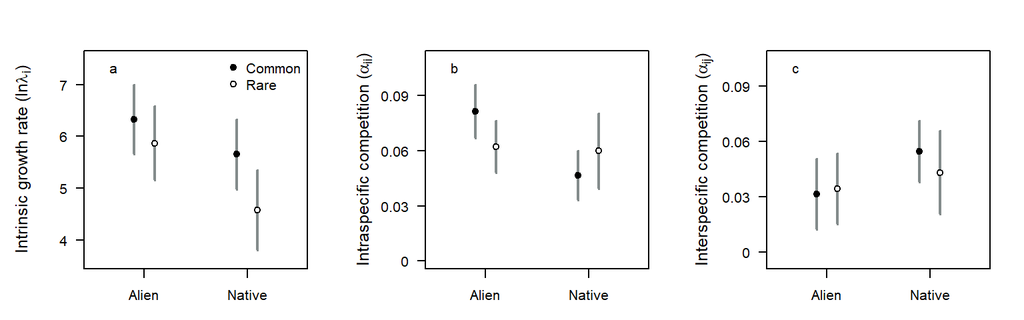

```r
par(mfrow=c(1,3),mar=c(3,5,3,2))
#fig settings

#lambda
#status:common
lambda$col<-c("black","white","black","white")
#for error bar
x<-c(0.5,0.6,1,1.1)
x1<-c(0.55,1.05)
#for bar
plot(x,lambda$mean,ylim=c(3.6,7.5),xlim=c(0.3,1.3),pch=19,xaxt="n",yaxt="n",
     ylab=expression(paste("Intrinsic growth rate (ln",lambda["i"],")")),xlab="",cex.lab=1.2,cex=0)

arrows(x,lambda$mean+1.96*lambda$se,x,lambda$mean-1.96*lambda$se,angle=90,code=3,length=0,lwd=2,col="azure4")
points(x,lambda$mean,cex=1,pch=21,bg=lambda$col)
axis(1,at=x1,labels=c("Alien","Native"),cex.axis=1)
axis(2,at=c(4,5,6,7),labels =c(4,5,6,7),las=2,cex.axis=1)
legend("topright",c("Common","Rare"),pch=21,pt.bg=c("black","white"),bty="n",cex=1)
legend("topleft","a",bty="n")


#alpha figures


#ii
#common:status
alphaii$col<-c("black","white","black","white")
#for error bar
x<-c(0.5,0.6,1,1.1)
x1<-c(0.55,1.05)
#for bar
plot(x,alphaii$mean,ylim=c(0,0.11),xlim=c(0.3,1.3),pch=19,xaxt="n",yaxt="n",
     ylab=expression(paste("Intraspecific competition (",alpha["ii"],")")),xlab="",cex.lab=1.2,cex=0)


arrows(x,alphaii$mean+1.96*alphaii$se,x,alphaii$mean-1.96*alphaii$se,angle=90,code=3,length=0,lwd=2,col="azure4")
points(x,alphaii$mean,cex=1,pch=21,bg=alphaii$col)
axis(1,at=x1,labels=c("Alien","Native"),cex.axis=1)
axis(2,at=c(0,0.03,0.06,0.09),labels =c(0,0.03,0.06,0.09),las=2,cex.axis=1)
legend("topleft","b",bty="n")



#ij
alphaij$col<-c("black","white","black","white")
#for error bar
x<-c(0.5,0.6,1,1.1)
x1<-c(0.55,1.05)
#for bar
plot(x,alphaij$mean,ylim=c(-0.005,0.105),xlim=c(0.3,1.3),pch=19,xaxt="n",yaxt="n",
     ylab=expression(paste("Interspecific competition (",alpha["ij"],")")),xlab="",cex.lab=1.2,cex=0)

arrows(x,alphaij$mean+1.96*alphaij$se,x,alphaij$mean-1.96*alphaij$se,angle=90,code=3,length=0,lwd=2,col="azure4")
points(x,alphaij$mean,cex=1,pch=21,bg=alphaij$col)
axis(1,at=x1,labels=c("Alien","Native"),cex.axis=1)
axis(2,at=c(0,0.03,0.06,0.09),labels =c(0,0.03,0.06,0.09),las=2,cex.axis=1)
legend("topleft","c",bty="n")
```

## 2.3 intra vs inter (Appendix S3)

### 2.3.1 table

```r
t.par.alpha<-full_join(dat.ii,dat.ij,by=c("common_comp","common","comb","family_comp","family","status","spp_target","spp_comp"))
t.par.alpha<-t.par.alpha%>%
  mutate(diff=-Estimate.x+Estimate.y)%>%#difference between intra and inter, positive values indicate higher intracompetition
  mutate(se=se.x+se.y)

m.intra.inter<-lmer(diff~status*common*common_comp+(1|family/spp_target)+(1|family_comp/spp_comp)+(1|comb),
                    weights = 1/(se.x^2*df.x+se.y^2*df.y),
                    data=t.par.alpha)
#2-way
m.intra.inter_r2<-update(m.intra.inter,.~.-status:common:common_comp)
#main effect
m.intra.inter_r3<-update(m.intra.inter_r2,.~status+common+common_comp+(1|family/spp_target)+(1|family_comp/spp_comp)+(1|comb))
#intercept,whether intra larger than inter
m.intra.inter_r4<-update(m.intra.inter_r3,.~1+(1|family/spp_target)+(1|family_comp/spp_comp)+(1|comb))
m.intra.inter_r5<-lmer(diff~-1+(1|family/spp_target)+(1|family_comp/spp_comp)+(1|comb),
                    weights = 1/(se.x^2*df.x+se.y^2*df.y),
                    data=t.par.alpha)
#LRT results
#3way
rbind(drop1(m.intra.inter_r3,test="Chisq")[-1,],
      drop1(m.intra.inter_r2,test="Chisq")[-1,],
      drop1(m.intra.inter,test="Chisq")[-1,])%>%
  kable(digits=3)
```

|  | Df | AIC | LRT | Pr(Chi) |
| --- | --- | --- | --- | --- |
| status | 1 | -288.897 | 4.678 | 0.031 |
| common | 1 | -293.569 | 0.006 | 0.937 |
| common_comp | 1 | -293.566 | 0.009 | 0.925 |
| status:common | 1 | -289.975 | 6.487 | 0.011 |
| status:common_comp | 1 | -296.436 | 0.027 | 0.870 |
| common:common_comp | 1 | -293.932 | 2.530 | 0.112 |
| status:common:common_comp | 1 | -294.463 | 2.167 | 0.141 |

```r
#intercept
cat("intercept")
```

```
## intercept
```

```r
anova(m.intra.inter_r4,m.intra.inter_r5)%>%
  kable(digits=3)
```

|  | Df | AIC | BIC | logLik | deviance | Chisq | Chi Df | Pr(>Chisq) |
| --- | --- | --- | --- | --- | --- | --- | --- | --- |
| m.intra.inter_r5 | 6 | -289.554 | -274.168 | 150.777 | -301.554 | NA | NA | NA |
| m.intra.inter_r4 | 7 | -292.838 | -274.888 | 153.419 | -306.838 | 5.284 | 1 | 0.022 |

```r
r2beta(m.intra.inter)
```

```
##                                    Effect   Rsq upper.CL lower.CL
## 1                                   Model 0.148    0.331    0.083
## 2                            statusnative 0.036    0.139    0.000
## 8 statusnative:commonrare:common_comprare 0.013    0.093    0.000
## 3                              commonrare 0.012    0.091    0.000
## 6            statusnative:common_comprare 0.009    0.082    0.000
## 5                 statusnative:commonrare 0.006    0.075    0.000
## 4                         common_comprare 0.000    0.053    0.000
## 7              commonrare:common_comprare 0.000    0.053    0.000
```

### 2.3.2 figure S6

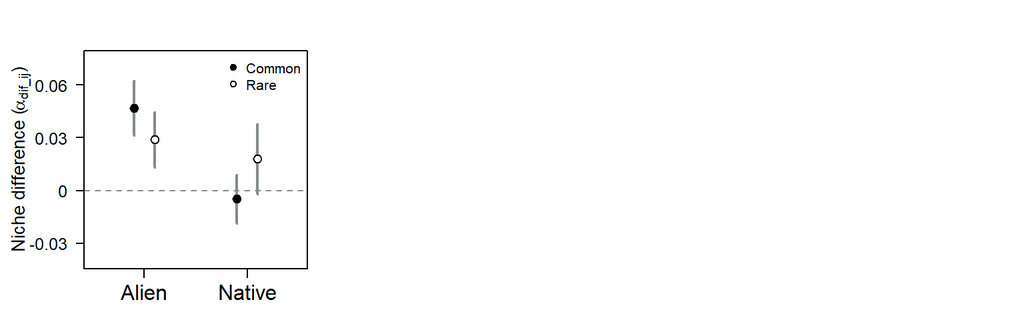

```r
par(mfrow=c(1,3),mar=c(3,5,3,2))
diff_ij<-as.data.frame(coef(summary(lmer(diff~common:status-1+(1|family/spp_target)+(1|comb),
                                             weights = 1/(se.x^2*df.x+se.y^2*df.y),
                                             data=t.par.alpha))))
names(diff_ij)[1:2]<-c("mean","se")
diff_ij$col<-c("black","white","black","white")
plot(x,diff_ij$mean,ylim=c(-0.04,0.075),xlim=c(0.3,1.3),pch=19,xaxt="n",yaxt="n",
     ylab=expression(paste("Niche difference (",alpha["dif_ij"],")")),xlab="",cex.lab=1.3,cex=0)
# barplot(t.diff$mean[,1],width=1,space=x2,ylim=c(-0.4,2.4),
#         ylab="ln(alien/native)",col=c("white","grey"),
#         lwd=1.5,cex.lab=1.8,cex.axis = 1.5)

arrows(x,diff_ij$mean+1.96*diff_ij$se,x,diff_ij$mean-1.96*diff_ij$se,angle=90,code=3,
       length=0,lwd=2,col="azure4")
points(x,diff_ij$mean,cex=1.4,pch=21,bg=diff_ij$col)
axis(1,at=x1,labels=c("Alien","Native"),cex.axis=1.5)
axis(2,at=c(-0.03,0,0.03,0.06,0.09),labels =c(-0.03,0.00,0.03,0.06,0.09),las=2,cex.axis=1.2)
legend("topright",c("Common","Rare"),pch=21,pt.bg=c("black","white"),bty="n",cex=1)
abline(h=0,lty=2,cex=1.5,col="azure4")
```

# 3 recruit~biomass association (Appendix S1)

```r
#data preparation, total biomass per sp per pot
dat_tb<-aggregate(biomass~spp_target+pot,data = dat0,FUN="sum")
dat_rec<-dat_rec%>%
  filter(!is.na(recruit),recruit!=0)%>%
  left_join(dat_tb,by=c("spp_target","pot"))
```

## 3.1 table

```r
dat.bio.rec<-dat_rec%>%
  filter(!is.na(biomass))
m.rec<-lmer(log(recruit)~common+status+log(biomass):(common+status)+log(biomass)+(1|family/spp_target)+(1|comb),
           data=dat.bio.rec)
r2beta(m.rec)
```

```
##                      Effect   Rsq upper.CL lower.CL
## 1                     Model 0.154    0.216    0.109
## 4              log(biomass) 0.008    0.030    0.000
## 2                commonrare 0.004    0.022    0.000
## 5   commonrare:log(biomass) 0.003    0.020    0.000
## 6 statusnative:log(biomass) 0.001    0.014    0.000
## 3              statusnative 0.000    0.009    0.000
```

```r
r1<-drop1(m.rec,test="Chisq")[-1,]
rec_r2<-update(m.rec,.~.-log(biomass):(common+status))
r2<-drop1(rec_r2,test="Chisq")[-c(1,4),]
rec_r3<-update(rec_r2,.~.-common-status)
r3<-drop1(rec_r3,test="Chisq")[-1,]
rbind(r3,r2,r1)%>%
  kable(caption="ln(recuit)~ln(biomass):(common+status)",digit=3)
```

ln(recuit)~ln(biomass):(common+status)

|  | Df | AIC | LRT | Pr(Chi) |
| --- | --- | --- | --- | --- |
| log(biomass) | 1 | 1485.184 | 14.794 | 0.000 |
| common | 1 | 1473.483 | 0.173 | 0.678 |
| status | 1 | 1474.380 | 1.069 | 0.301 |
| common:log(biomass) | 1 | 1475.097 | 1.750 | 0.186 |
| status:log(biomass) | 1 | 1473.826 | 0.479 | 0.489 |

## 3.2 figure S2

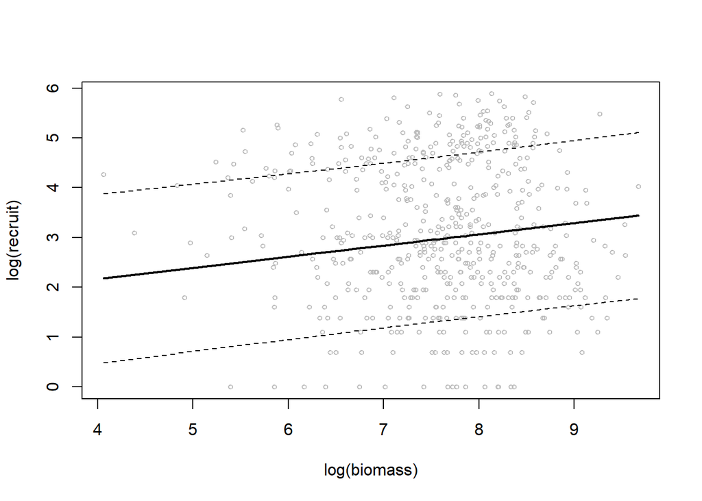

```r
newdat<-expand.grid(recruit=0,
                    spp_target=unique(dat.bio.rec$spp_target),
                    family=unique(dat.bio.rec$family),
                    biomass=seq(min(dat.bio.rec$biomass),max(dat.bio.rec$biomass),length=100))%>%
  filter(!(family=="Poa"&spp_target%in%c("Bid.fro","Gal.par","Bid.tri")))%>%
  filter(!(family=="Comp"&spp_target%in%c("Vul.bro","Vul.myu","Era.min","Tra.rac","Bro.jap")))

mm<-model.matrix(terms(rec_r3),newdat)
newdat$recruit<-mm%*%fixef(rec_r3) #predict(m,newdat,re.form=NA) would give the same results
pvar1 <- diag(mm %*% tcrossprod(vcov(rec_r3),mm))

## must be adapted for more complex models

newdat <- data.frame(
  newdat
  , plo = newdat$recruit-1.96*sqrt(pvar1)
  , phi = newdat$recruit+1.96*sqrt(pvar1)
)


plot(log(recruit)~log(biomass),dat.bio.rec,cex=0.6,col="grey")
lines(log(newdat$biomass),newdat$recruit,col="black",lty=1,lwd=2)
lines(log(newdat$biomass),newdat$plo,col="black",lty=2,lwd=1)
lines(log(newdat$biomass),newdat$phi,col="black",lty=2,lwd=1)
```

# 4 fitness differece (Appendix S2)

A method adpated from Saavedra et al 2017 ecol mon

```r
#functions
#vector defining the centroid of the feasibility domain
r_centroid <- function(alpha){
  n <- nrow(alpha)
  D <- diag(1/sqrt(diag(t(alpha)%*%alpha)))
  alpha_n <- alpha %*% D
  r_c <- rowSums(alpha_n) /n
  r_c <- t(t(r_c))
  return(r_c)
}
```

## 4.1 calculation

```r
fit_niche<-data.frame(matrix(,48,11))
#order the t.par2 according to common_rare categoried
#this is fro categorizing the plots
dat_par_order<-dat_par%>%
  arrange(status,common,common_comp,spp_target)
comb_uniq<-unique(dat_par_order$comb)

names(fit_niche)<-c("common_A","common_N","fam_A","fam_N","spp_A","spp_N","comb",
                    "angle","v_angle","r_diff","v_r")
for (i in 1:48){
  dat.i<-filter(dat_par_order,comb==comb_uniq[i])
  #if we say native is sp1, alien is sp2,
  #p.i: alpha11, alpha21, alpha12,alpha22
  p.i<-(-dat.i[c(5,3,6,2),10])
  alpha.i<-matrix(p.i$Estimate,2,2)#alpha matrix
  r.i<-dat.i[c(4,1),10]#intrinsic vector
  centroid.i<-r_centroid(alpha.i)#centroid of niche difference dormain
  vector_base<-matrix(c(1,1),2,1)#vector [1,1]
  # angle from vector [1,1] to centroid, negative if counterclockwise, i.e. alien is less sensitive
  angle.i<-atan2(det(matrix(c(vector_base,centroid.i),2,2)),sum(vector_base*centroid.i))
  #change the sign of angle.i, so that a positive value indicates that alien is less sensitive, and thus more competitive.
  angle.i<--angle.i
  fit_niche[i,8]<-angle.i
    #infomation
  for (j in 1:7){
    fit_niche[i,j]<-as.character(dat.i[1,j+1])
  }
  fit_niche[i,9]<-sum(dat.i$se[c(-1,-4)]^2*dat.i$df[c(-1,-4)])#variances for alphas
  fit_niche[i,10]<-r.i$Estimate[2]-r.i$Estimate[1]#r_diff, postive if r alien is lager
  fit_niche[i,11]<-sum(dat.i$se[c(1,4)]^2*dat.i$df[c(1,4)])#variances for lambdas
}
```

## 4.2 demographic difference

Same with intrinsic growth rates

```r
m_dem<-lmer(r_diff~common_A*common_N+(1|fam_A/spp_A)+(1|fam_N/spp_N),
            weights = 1/(v_r),
               data=fit_niche)
m_dem_r2<-update(m_dem,.~.-common_A:common_N)
m_dem_r3<-update(m_dem_r2,.~.-common_A:common_N)
m_dem_r4<-lmer(r_diff~-1+(1|fam_A/spp_A)+(1|fam_N/spp_N),
            weights = 1/(v_r),
               data=fit_niche)
r1<-drop1(m_dem,test="Chisq")[-1,]
r2<-drop1(m_dem_r2,test="Chisq")
r3<-anova(m_dem_r4,m_dem_r3)
rownames(r2)[1]<-"intercept"
r2$Df[1]<-1
r2$AIC[1]<-NA
r2$LRT[1]<-r3$Chisq[2]
r2$`Pr(Chi)`[1]<-r3$`Pr(>Chisq)`[2]
rbind(r2,r1)%>%
  kable(digits=3)
```

|  | Df | AIC | LRT | Pr(Chi) |
| --- | --- | --- | --- | --- |
| intercept | 1 | NA | 9.986 | 0.019 |
| common_A | 1 | 129.379 | 3.656 | 0.056 |
| common_N | 1 | 130.530 | 4.807 | 0.028 |
| common_A:common_N | 1 | 127.723 | 0.071 | 0.791 |

## 4.3 difference in sensitivity to competition

```r
m_comp<-lmer(angle~common_A*common_N+(1|fam_A/spp_A)+(1|fam_N/spp_N),
            weights = 1/(v_angle),
               data=fit_niche)
m_comp_r2<-update(m_comp,.~.-common_A:common_N)
m_comp_r3<-update(m_comp_r2,.~.-common_A:common_N)
m_comp_r4<-lmer(angle~-1+(1|fam_A/spp_A)+(1|fam_N/spp_N),
            weights = 1/(v_angle),
               data=fit_niche)
r1<-drop1(m_comp,test="Chisq")[-1,]
r2<-drop1(m_comp_r2,test="Chisq")
r3<-anova(m_comp_r4,m_comp_r3)
rownames(r2)[1]<-"intercept"
r2$Df[1]<-1
r2$AIC[1]<-NA
r2$LRT[1]<-r3$Chisq[2]
r2$`Pr(Chi)`[1]<-r3$`Pr(>Chisq)`[2]
rbind(r2,r1)%>%
  kable(digits=3)
```

|  | Df | AIC | LRT | Pr(Chi) |
| --- | --- | --- | --- | --- |
| intercept | 1 | NA | 4.185 | 0.242 |
| common_A | 1 | 117.485 | 0.884 | 0.347 |
| common_N | 1 | 119.714 | 3.113 | 0.078 |
| common_A:common_N | 1 | 118.601 | 1.623 | 0.203 |

```r
r2beta(m_comp)
```

```
##                Effect   Rsq upper.CL lower.CL
## 1               Model 0.090    0.318    0.019
## 3           common_N2 0.070    0.256    0.001
## 4 common_A2:common_N2 0.024    0.174    0.000
## 2           common_A2 0.000    0.103    0.000
```

```r
r2beta(m_dem)
```

```
##                Effect   Rsq upper.CL lower.CL
## 1               Model 0.331    0.545    0.164
## 3           common_N2 0.183    0.393    0.033
## 2           common_A2 0.028    0.183    0.000
## 4 common_A2:common_N2 0.001    0.105    0.000
```

## 4.4 figure S5

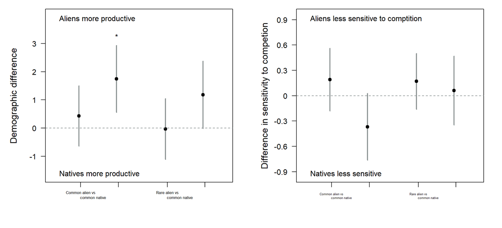

```r
#figure
par(mfrow=c(1,2),mar=c(5,5,1,2))
#demographic difference
dem.diff<-as.data.frame(coef(summary(lmer(r_diff~common_N:common_A-1+(1|fam_A/spp_A)+(1|fam_N/spp_N),
            weights = 1/(v_r),
               data=fit_niche))))

colnames(dem.diff)[1:2]<-c("mean","se")

#for bar
x<-c(0.5,1.5,2.8,3.8)
plot(x+0.2,dem.diff$mean,ylim=c(-1.7,4),xlim=c(0,4.6),pch=19,xaxt="n",yaxt="n",
     ylab="Demographic difference",xlab="",cex.lab=1.2)

arrows(x+0.2,dem.diff$mean+1.96*dem.diff$se,x+0.2,dem.diff$mean-1.96*dem.diff$se,angle=90,code=3,length=0,lwd=2,col="azure4")
points(x+0.2,dem.diff$mean,ylim=c(-1.6,3.5),xlim=c(0,4),pch=21,bg="black",cex=1)
axis(1,at=x+0.25,labels=c("Common alien vs
                     common native","Common alien vs
                     rare native","Rare alien vs
                     common native","Rare alien vs
                     rare native"
),cex.axis=0.54)
axis(2,at=c(-1,0,1,2,3),labels = c(-1,0,1,2,3),las=2)
abline(h=0,lty=2, col="azure4",cex=1.5)
legend("topleft","Aliens more productive",bty="n")
legend("bottomleft","Natives more productive",bty="n")
text(1.7,3.3,"*")

## sensitivity
comp.diff<-as.data.frame(coef(summary(lmer(angle~common_N:common_A-1+(1|fam_A/spp_A)+(1|fam_N/spp_N),
            weights = 1/(v_angle),
               data=fit_niche))))

colnames(comp.diff)[1:2]<-c("mean","se")

plot(x+0.2,comp.diff$mean,ylim=c(-0.95,0.95),xlim=c(0,4.6),pch=19,xaxt="n",yaxt="n",
     ylab="Difference in sensitivity to competion",xlab="",cex.lab=1.2)

arrows(x+0.2,comp.diff$mean+1.96*comp.diff$se,x+0.2,comp.diff$mean-1.96*comp.diff$se,angle=90,code=3,length=0,lwd=2,col="azure4")
points(x+0.2,comp.diff$mean,ylim=c(-0.95,0.95),xlim=c(0,4),pch=21,bg="black",cex=1)
axis(1,at=x+0.25,labels=c("Common alien vs
                     common native","Common alien vs
                     rare native","Rare alien vs
                     common native","Rare alien vs
                     rare native"
),cex.axis=0.4)
axis(2,at=c(-0.9,-0.6,-0.3,0,0.3,0.6,0.9),labels = c(-0.9,-0.6,-0.3,0,0.3,0.6,0.9),las=2)
abline(h=0,lty=2, col="azure4",cex=1.5)
legend("topleft","Aliens less sensitive to comptition",bty="n")
legend("bottomleft","Natives less sensitive",bty="n")
```